# Exploration of the NOAA Storm dataset

NAME: Todd Himple

DATE: September 22, 2016

## Inroduction

Storms and other severe weather events can cause both public health and economic problems for communities and municipalities. Many severe events can result in fatalities, injuries, and property damage, and preventing such outcomes to the extent possible is a key concern.

This project involves exploring the U.S. National Oceanic and Atmospheric Administration’s (NOAA) storm database. This database tracks characteristics of major storms and weather events in the United States, including when and where they occur, as well as estimates of any fatalities, injuries, and property damage

The basic goal is to explore the NOAA Storm Database and determine the following:

```
    * Which type of events are most harmful with respect to population health?
    * Which types of events cause the greatest economic consequences?
```

## Performing initial set-up Loading the appropriate R packages

```r
##Loading R packages
library(knitr)
library(markdown)
library(rmarkdown)
library(plyr)
library(stats)

##Capturing HW & SW Information software used to derive theses results
```

## Loading the NOAA dataset and Reference material

Obtaining original data, as well as reference material that will be useful in data interpretation. The events in the database represent storms in the US, and run from 1950 to November 2011

```r
#Data Download
fileUrl <- "https://d396qusza40orc.cloudfront.net/repdata%2Fdata%2FStormData.csv.bz2"
download.file(fileUrl, destfile = "FStormData.csv.bz2")
dateDownloaded <- date() #capturing download date
dateDownloaded
```

```
## [1] "Thu Sep 22 15:36:27 2016"
```

```r
#Reading data into R
storm_data <- read.csv("FStormData.csv.bz2")

#Downloading reference material
fileUrl_instructions <- "https://d396qusza40orc.cloudfront.net/repdata%2Fpeer2_doc%2Fpd01016005curr.pdf"
download.file(fileUrl_instructions, destfile = "NOAA_Data_Instructions.pdf")

fileUrl_FAQ <- "https://d396qusza40orc.cloudfront.net/repdata%2Fpeer2_doc%2Fpd01016005curr.pdf"
download.file(fileUrl_FAQ, destfile = "NOAA_Data_FAQ.pdf")
```

## Subsetting useful fields & performing data cleansing

```r
Neededvariables <- c("BGN_DATE", "EVTYPE", "FATALITIES", "INJURIES", "PROPDMG", "PROPDMGEXP", "CROPDMG", "CROPDMGEXP")
storm_data_2 <- storm_data[Neededvariables]
##dim(storm_data_2)
##head(storm_data_2)

##Convert the date into date class
storm_data_2$BGN_DATE<-as.Date(storm_data_2$BGN_DATE, "%m/%d/%Y")



storm_data_2[storm_data_2$PROPDMGEXP == "K", ]$PROPDMG <- storm_data_2[storm_data_2$PROPDMGEXP == "K", ]$PROPDMG * 1000
storm_data_2[storm_data_2$PROPDMGEXP == "k", ]$PROPDMG <- storm_data_2[storm_data_2$PROPDMGEXP == "k", ]$PROPDMG * 1000
storm_data_2[storm_data_2$PROPDMGEXP == "M", ]$PROPDMG <- storm_data_2[storm_data_2$PROPDMGEXP == "M", ]$PROPDMG * 1000000
storm_data_2[storm_data_2$PROPDMGEXP == "m", ]$PROPDMG <- storm_data_2[storm_data_2$PROPDMGEXP == "m", ]$PROPDMG * 1000000
storm_data_2[storm_data_2$PROPDMGEXP == "B", ]$PROPDMG <- storm_data_2[storm_data_2$PROPDMGEXP == "B", ]$PROPDMG * 1000000000
storm_data_2[storm_data_2$PROPDMGEXP == "b", ]$PROPDMG <- storm_data_2[storm_data_2$PROPDMGEXP == "b", ]$PROPDMG * 1000000000

storm_data_2[storm_data_2$CROPDMGEXP == "K", ]$CROPDMG <- storm_data_2[storm_data_2$CROPDMGEXP == "K", ]$CROPDMG * 1000
storm_data_2[storm_data_2$CROPDMGEXP == "k", ]$CROPDMG <- storm_data_2[storm_data_2$CROPDMGEXP == "k", ]$CROPDMG * 1000
storm_data_2[storm_data_2$CROPDMGEXP == "M", ]$CROPDMG <- storm_data_2[storm_data_2$CROPDMGEXP == "M", ]$CROPDMG * 1000000
storm_data_2[storm_data_2$CROPDMGEXP == "m", ]$CROPDMG <- storm_data_2[storm_data_2$CROPDMGEXP == "m", ]$CROPDMG * 1000000
storm_data_2[storm_data_2$CROPDMGEXP == "B", ]$CROPDMG <- storm_data_2[storm_data_2$CROPDMGEXP == "B", ]$CROPDMG * 1000000000
storm_data_2[storm_data_2$CROPDMGEXP == "b", ]$CROPDMG <- storm_data_2[storm_data_2$CROPDMGEXP == "b", ]$CROPDMG * 1000000000
```

### Processing the data for aggregation and graphing

```r
##Fatality and injury
sumFatalities <- aggregate(FATALITIES ~ EVTYPE, data = storm_data_2,  FUN="sum")
top5fatalities <- sumFatalities[order(-sumFatalities$FATALITIES), ][1:5, ]

sumInjuries <- aggregate(INJURIES ~ EVTYPE, data = storm_data_2,  FUN="sum")
top5injuries <- sumInjuries[order(-sumInjuries$INJURIES), ][1:5, ]


##Property and crop damage
PropertyDamage <- aggregate(PROPDMG ~ EVTYPE, data = storm_data_2,  FUN="sum")
top5propdamage <- PropertyDamage[order(-PropertyDamage$PROPDMG), ][1:5, ]


CropDamage <- aggregate(CROPDMG ~ EVTYPE, data = storm_data_2,  FUN="sum")
top5cropdamage <- CropDamage[order(-CropDamage$CROPDMG), ][1:5, ]
```

### Plotting top events related to population health

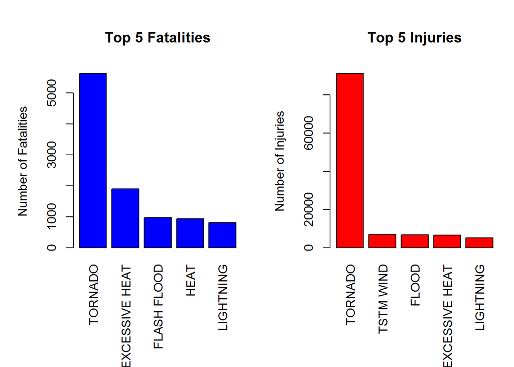

```r
par(mfrow = c(1,2), mar = c(8,5,5,1))

barplot(top5fatalities$FATALITIES, names.arg = top5fatalities$EVTYPE, las = 3,
        main = "Top 5 Fatalities", ylab = "Number of Fatalities", col="blue")

barplot(top5injuries$INJURIES, names.arg = top5injuries$EVTYPE, las = 3,
        main = "Top 5 Injuries", ylab = "Number of Injuries", col="red")
```

### Plotting top events related to economic consequences

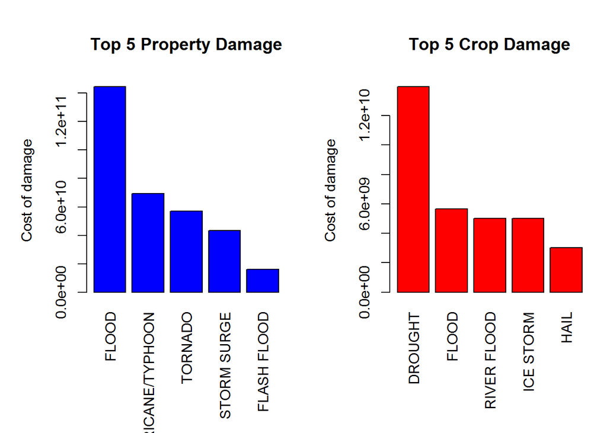

```r
par(mfrow = c(1,2), mar = c(8,5,5,1))

barplot(top5propdamage$PROPDMG, names.arg = top5propdamage$EVTYPE, las = 3,
        main = "Top 5 Property Damage", ylab = "Cost of damage", col="blue")

barplot(top5cropdamage$CROPDMG, names.arg = top5cropdamage$EVTYPE, las = 3,
        main = "Top 5 Crop Damage", ylab = "Cost of damage", col="red")
```

### Conclusions

In response to the question, “Which types of events cause the greatest economic consequences?” the data show taht floods have the greatest impact on property damage, while droughts have the greatest impact on crops.